# MATH 340: Continuous Random Variables

Hitchman

# Continuous Random Variables

Below we investigate the common named continuous random variables we encounter in MATH 340.

- Uniform probability distribution | `unif`
- Normal probability distribution | `norm`
- Gamma probability distribution | `gamma`
- Exponential probability distribution | `exp`
- Chi-square probability distribution | `chisq`
- Beta probability distribution | `beta`

For each of these distributions we may use the 4 associated commands:

- `d___()` gives the density function
- `p___()` gives cumulative probability
- `q___()` gives quantiles
- `r___()` gives random samples

We also discuss below how to build and analyze homemade continuous random variables in R.

# Uniform Distribution

The uniform distribution is so very useful, it deserves top-billing here. With it we can generate random numbers, and from it we can build other interesting distributions.

A uniform random variable $X$ over the interval $[a,b]$ has density function
$$f(x) = \frac{1}{b-a}, ~~\text{ for
all }~~ a \leq x \leq b.$$

## Picking random numbers!

```r
runif(10,0,1) #pick 10 random numbers between 0 and 1.
```

```
##  [1] 0.7199107 0.5411312 0.3608600 0.8409847 0.6448883 0.3060240 0.1448780
##  [8] 0.1285950 0.4225624 0.5483953
```

## Picking random points in the unit square!

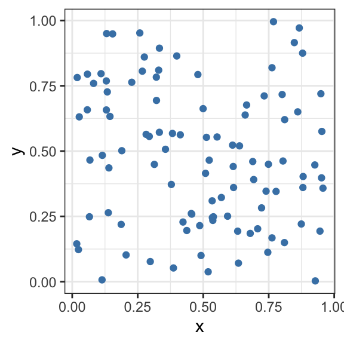

```r
ggplot(data.frame(x=runif(100,0,1),
                 y=runif(100,0,1)))+
  geom_point(aes(x,y),col="steelblue")+
  theme_bw()
```

## Estimate the value of $\pi$

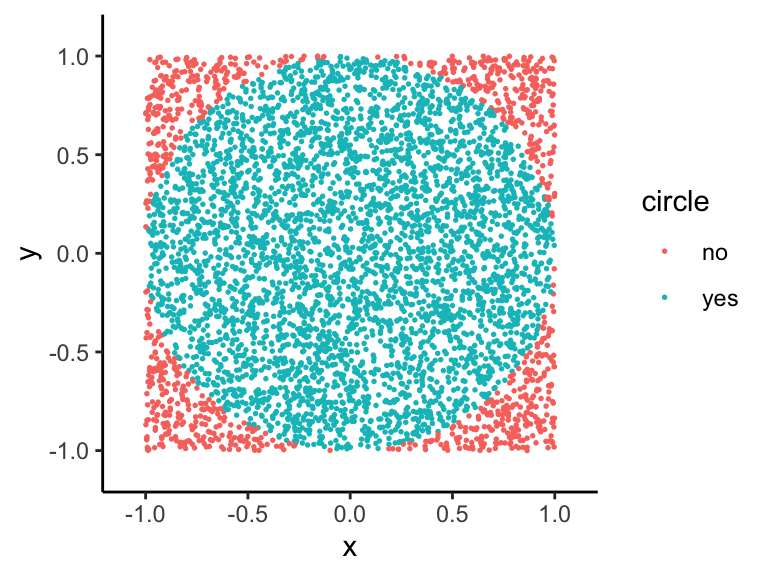

```r
points=5000
df <- data.frame(x=runif(points,-1,1),
                 y=runif(points,-1,1))
df$circle <- ifelse(sqrt(df$x^2+df$y^2)<1,"yes","no")
ggplot(df)+
  geom_point(aes(x,y,col=circle),size=.3)+
  xlim(c(-1.1,1.1))+ylim(c(-1.1,1.1))+
  theme_classic()
```

The area of the square is 2*2 = 4. The area of the circle is $\pi (1)^2 = \pi.$ So the ratio
$$\text{(area of circle)/(area of
square)}=\pi/4,$$
and we can estimate $\pi$ as follows:
$$\pi \approx 4\cdot \frac{\text{points in
circle}}{\text{total points}}$$

```r
4*sum(df$circle=="yes")/points # our estimate of pi
```

```
## [1] 3.172
```

# Normal Distribution `norm`

Thanks to the Central Limit Theorem this distribution has a central role in statistics.

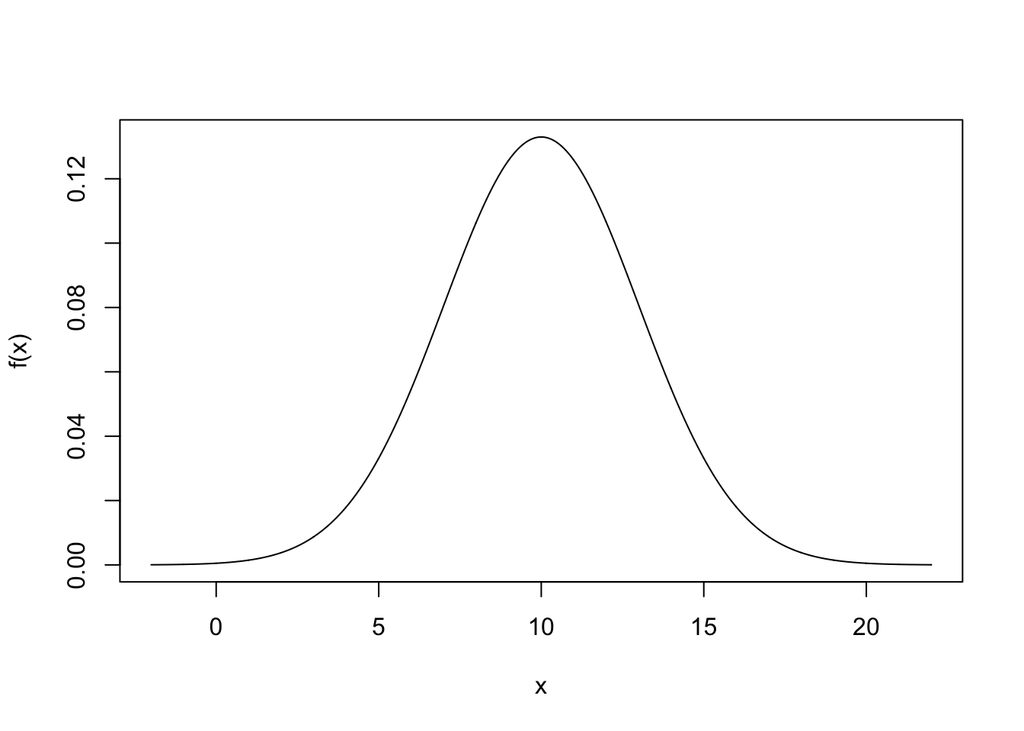

```r
mu=10; sigma=3
x=seq(mu-4*sigma,mu+4*sigma,by=.01)
plot(x,dnorm(x,mu,sigma),type="l",ylab="f(x)")
```

> **Example**: Suppose newborn birthweights are normally distributed with mean 7.8 pounds and standard deviation 0.95 pounds.  
> a) What proportion of newborns weight more than 10 pounds?  
> b) Find the birth weight that marks the bottom 1% of all birthweights.

```r
# part (a)
1-pnorm(10,mean=7.8,sd=0.95)
```

```
## [1] 0.01028488
```

```r
# part (b)
qnorm(.01,mean=7.8, sd=0.95)
```

```
## [1] 5.58997
```

## Sampling Distribution of a sample mean

Suppose we have a population of 5000 random numbers between 10 and 20, which should have a uniform looking frequency distribution:

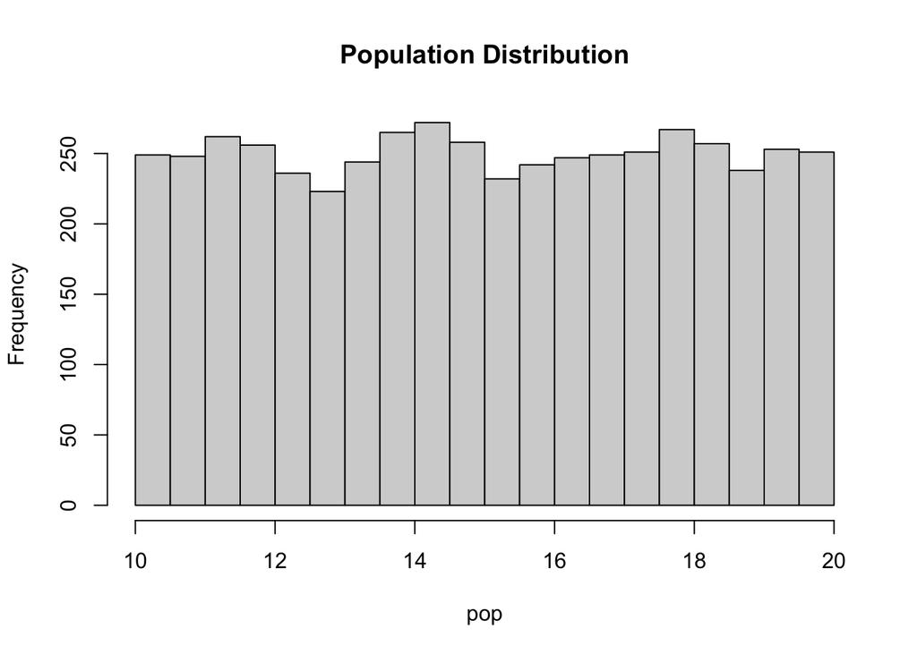

```r
pop=runif(5000,10,20)
hist(pop,breaks=15, main="Population Distribution")
```

Now suppose we draw a sample of size 50 from this population, and compute the sample mean of these 50 values:

```r
mean(sample(pop,50))
```

```
## [1] 15.35935
```

Now let’s do that game for 10000 trials, and look at the distribution of 10000 sample means:

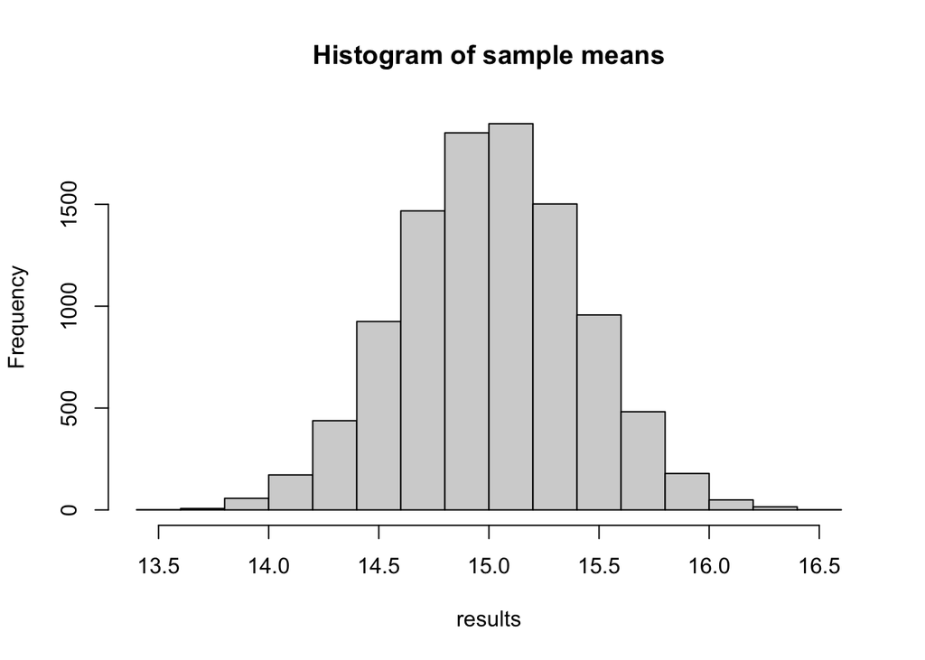

```r
trials=10000
results=c()
for (i in 1:trials){
  results=c(results,mean(sample(pop,50)))
}
hist(results, main="Histogram of sample means")
```

Look Normal?

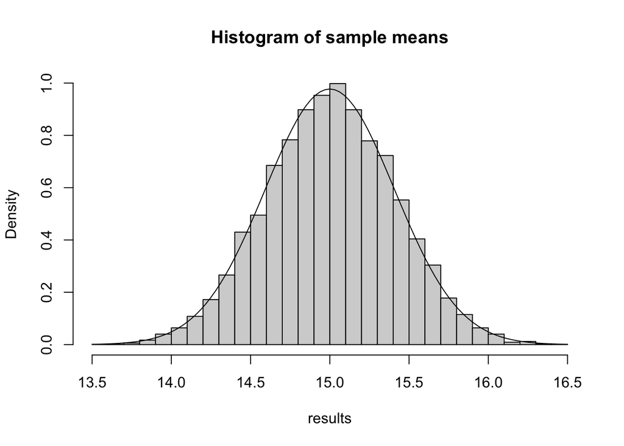

```r
x=seq(12,18,by=.05)
hist(results, main="Histogram of sample means",freq=FALSE,breaks=30)
curve(dnorm(x,15,10/sqrt(12)/sqrt(50)),add=TRUE)
```

# Exponential Distribution `exp`

An exponential random variable $X$ with parameter $\beta$ has pdf
$$f(x) = \frac{1}{\beta}e^{-x/\beta} ~~\text{ for
}~~ x > 0$$

The **mean** of this distribution is $E(X) = \beta$ and the **rate** associated to this distribution is $1/\beta$. **In R**, we specify the exponential parameter by entering the rate $1/\beta$, not $\beta$ itself.

> Suppose $X$ is exp($b$).  
> **In R**, $P(X \leq q)$ is given by `pexp(q,1/b)`

> **Example**: The life of a lightbulb is exponentially distributed with mean 120 hours. What is the probability that it lasts more than 200 hours?

Here $X$ is exponential with parameter $\beta = 120$. The rate associated with this distribution is 1/120, so $P(X > 200)$ can be computed with

```r
1-pexp(200,rate=1/120)
```

```
## [1] 0.1888756
```

As a reminder, this probability corresponds to the integral
$$\int_{200}^\infty
\frac{1}{120}e^{-x/120}~dx$$
which corresponds to the shaded area below

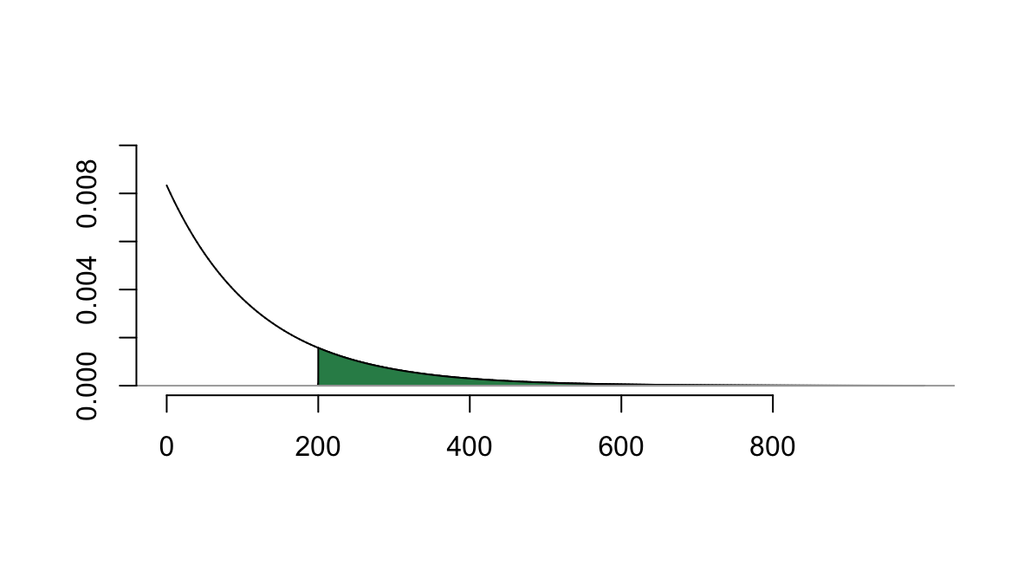

> **Example**: What proportion of lightbulbs last fewer than 5 hours?

```r
pexp(5,1/120)
```

```
## [1] 0.04081054
```

> **Example**: Find the 5th percentile for this distribution.

```r
qexp(.05,1/120)
```

```
## [1] 6.155195
```

So, 5% of lightbulbs last less than 6.16 hours.

> **Example**: Suppose $X$ is an exponential random variable with parameter $\beta = 2$. Sketch the density function $f(x)$ as well as the distribution function $F(x)$.

The density function is $f(x) = \frac{1}{2}e^{-x/2}$ for $x > 0$, and we can sketch it by plotting an $x$ vector of many inputs between, say, 0 and 10, and the corresponding values of `dexp()`:

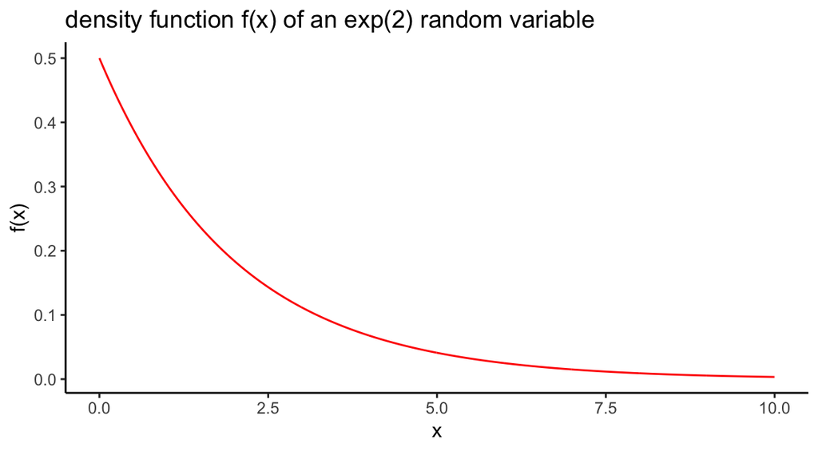

The distribution function, which gives cumulative probability is found by plotting `pexp()`:

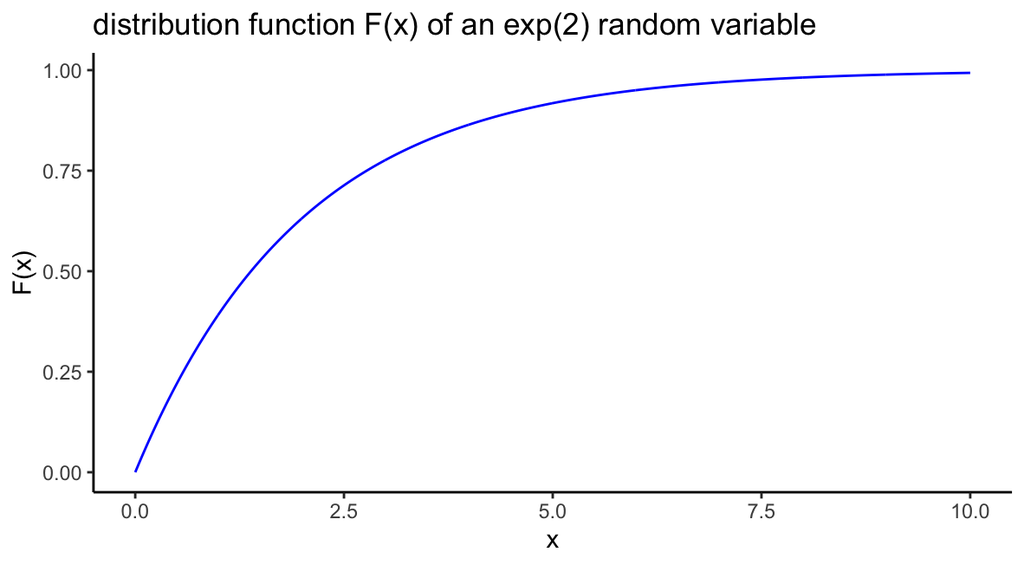

# Gamma Distribution `gamma`

Some random variables are always nonnegative, and yield distributions of data that are skewed right, as pictured below.

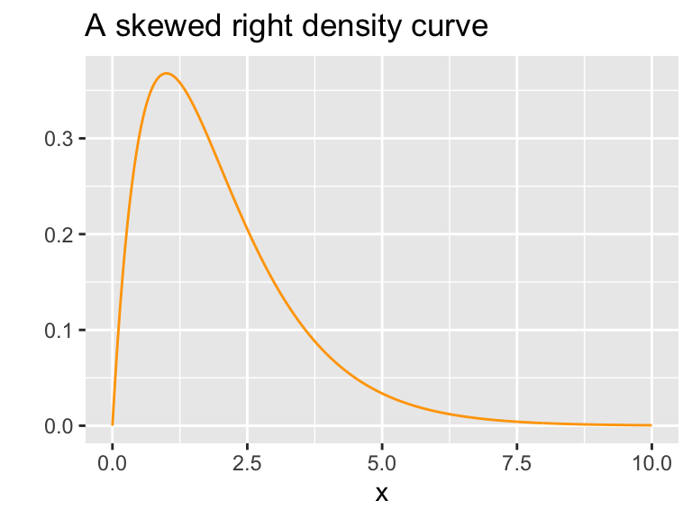

Some typically skewed right distributions include household incomes in a city, the length of time between malfunctions of some machine, and major league baseball salaries. The gamma probability distribution, which has two parameters $\alpha$ and $\beta$, can model such skewed right distributions. The parameter $\alpha$ is sometimes called the **shape** parameter, $\beta$ is called the **scale** parameter, and its reciprocal $1/\beta$ is called the **rate**.

Here are plots of three different gamma distributions.

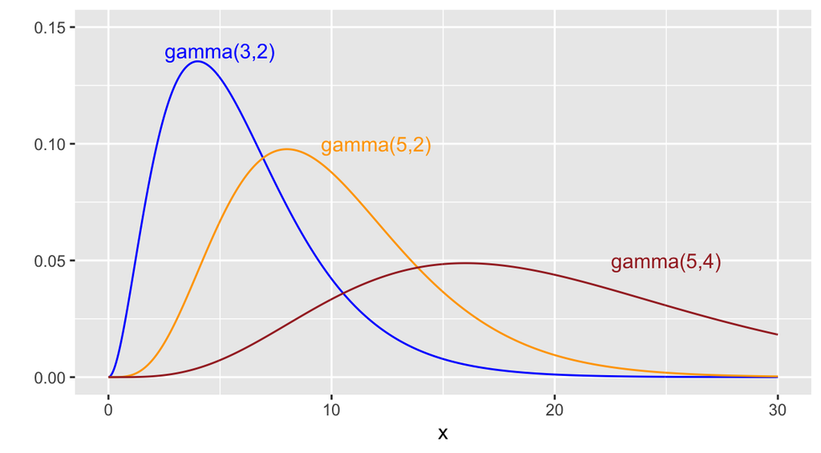

> Suppose $X$ is gamma($a,b$).  
> **In R**, $P(X \leq q)$ is given by `pgamma(q,a,1/b)`

> **Example** Suppose $X$ has a gamma distribution with parameters $\alpha=3$ and $\beta = 4$. Find $P(4\leq X < 12)$, which corresponds to the area pictured below.

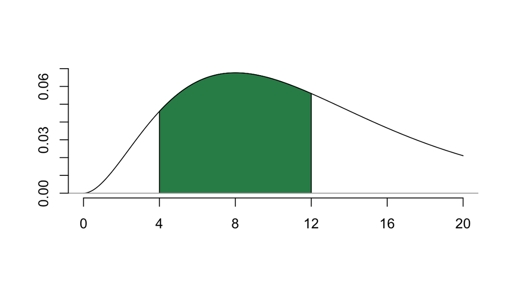

No need for Riemann Sum estimates of this area, we have the built in gamma function.

```r
alpha=3; beta=4
pgamma(12,alpha,1/beta)-pgamma(4,alpha,1/beta)
```

```
## [1] 0.4965085
```

Just about a 50% chance that a random value from a gamma(3,4) distribution is between 4 and 12. Ok, so if we gather a random sample of say 1000 values from this distribution, we’d expect somehwere around 500 of them between 4 and 12:

```r
x=rgamma(1000,3,1/4) # random sample of size 1000
sum(abs(x-8)<4) # values in the sample between 4 and 12
```

```
## [1] 485
```

Well, 485 is mighty close to half of the 1000 values!

**Exponential distributions are special gamma distributions.** In particular, if we set $\alpha=1$, the gamma distribution gamma(1,$\beta$) is exactly equal to the exponential distribution exp($\beta$).

# Chi-square Distribution `chisq`

Like the exponential distribution, the chi-square distribution is a special gamma distribution. For a positive integer $\nu$, the **Chi-square probability distribution with degrees of freedom $\nu$**, denoted $\chi^2(\nu)$, is the gamma distribution with $\alpha = \nu/2$ and $\beta=2$.

Here are plots of three different chi-square distributions.

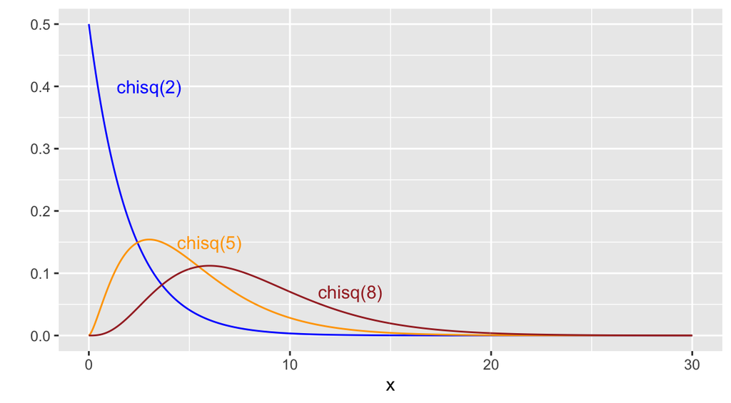

# Beta distribution `beta`

The beta$(\alpha,\beta)$ probability distribution provides a way to model random variables whose possible outcomes are all real numbers betweeen 0 and 1. Such distributions are useful for modeling proportions. As with the gamma and normal distributions, this is a 2-parameter family of distributions. Altering the shape parameters $\alpha$ and $\beta$ gives us, well, different shapes for the density curves.

We note that **beta(1,1) corresponds to the uniform distribution on the interval (0,1)**. Here are plots of density functions for four other beta distributions.

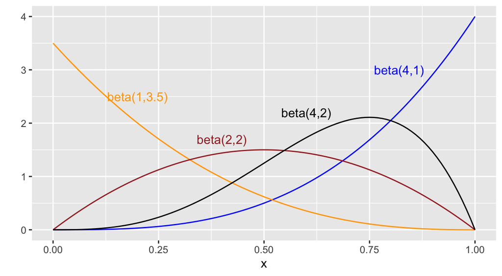

```r
t=seq(0,1,by=.01)
x1=dbeta(t,4,1)
x2=dbeta(t,1,3.5)
x3=dbeta(t,2,2)
x4=dbeta(t,4,2)
ggplot(data.frame(t,x1,x2,x3))+
  geom_line(aes(t,x1),col="blue")+
  geom_line(aes(t,x2),col="orange")+
  geom_line(aes(t,x3),col="brown")+
  geom_line(aes(t,x4),col="black")+
  ylim(c(0,4))+
  ylab("")+xlab("x")+
  annotate("text", x = c(.82,.2,.4,.6), y = c(3,2.5,1.7,2.2), label = c("beta(4,1)","beta(1,3.5)","beta(2,2)","beta(4,2)"),col=c("blue","orange","brown","black"))
```

> **Example** Let $X$ denotes the proportion of sales on a particular website that comes from new customers any given day, and suppose from past experience, $X$ is well-modeled with a beta distribution with shape parameters $\alpha = 1$, and $\beta=3.5$. Determine the probability that on any given day, over 1/2 the sales come from new customers.

```r
1-pbeta(0.5,1,3.5)
```

```
## [1] 0.08838835
```

# Homemade Continuous Random Variables

We may wish to study a continuous random variable $X$ from a given probability density function such as $f(x) = \frac{3}{8}(2-x)^2$ for $0 \leq x \leq 2$.

In this case, probabilities such as $P(X > 1.2)$ correspond to areas under the density curve, which are calculated by integration, e.g.,
$$P(X
> 1.2) = \int_{1.2}^2 \frac{3}{8}(2-x)^2~dx.$$

If we can find an antiderivative of $f(x)$, we can find this probability using the fundamental theorem of calculus. If not, we can always estimate the value of the integral with Riemann sums. We do this below.

## Input the density function

First build the probability density function (pdf) as a function in R.

```r
f_pdf <- function(x){
  return(3*(2-x)^2/8)
}
```

## Visualize the density function

We create a vector of inputs `x` going from 0 to 2 in small increments (the increment is .01 below), to give us many points over the interval of interest [0,2]. Then we **plot the density curve** by plotting these x values against the function values f(x). (`type="l"` gives us a **l**ine plot instead of a point plot).

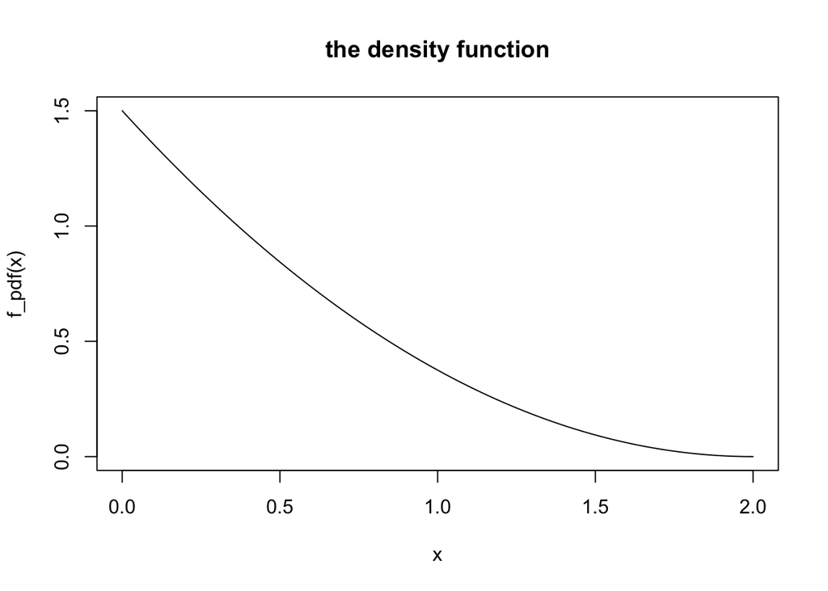

```r
x=seq(0,2,by=.01)
plot(x,f_pdf(x),type="l",
     main="the density function")
```

## Estimating Integrals with Riemann Sums

We know $P(X \geq 1.2)$ corresponds to the area under the density curve between 1.2 and 2. We can estimate areas by computing a Riemann Sum (a sum of many thin rectangle areas approximating the area under the density curve).

Here’s a function for estimating $\int_a^b f(x)~dx$ with a sum of $n$ rectangle areas, generated using the midpoint rule.

```r
mid.sum=function(f,a,b,n){
  #inputs:
      #f - function
      #a, b - lower and upper bounds of interval
      #n - number of subdivisions
  #output: The sum of the n rectangle areas whose heights are
  # determined by the midpoint rule
  dx=(b-a)/n
  ticks=seq(a+dx/2,b,dx)
  return(sum(f(ticks)*dx))
}
```

For instance, `mid.sum(f_pdf,a=0.4,b=1.2,n=4)` computes the area of the 4 rectangles pictured below. We divide the interval [0.4,1.2] into n=4 equal-width subintervals, and build rectangles having height equal to the function height at the midpoint of each of these subintervals.

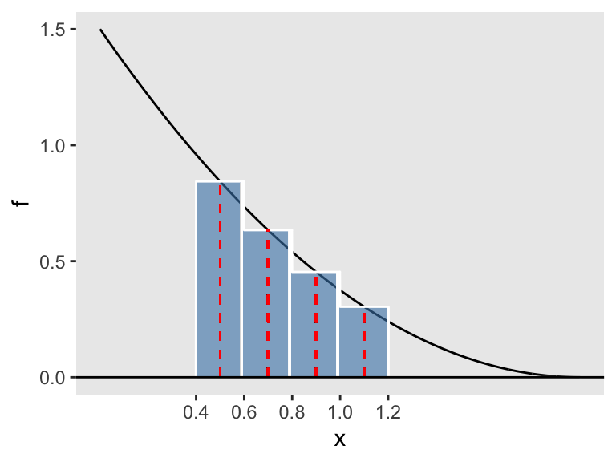

The area of the four rectangles is

```r
mid.sum(f_pdf,a=.4,b=1.2,n=4)
```

```
## [1] 0.447
```

## Estimating Probabilities

So, getting back to our example, if we want to estimate $P(X > 1.2)$ we can compute a midpoint sum - the more rectangles the better. Let’s start with $n = 100$:

```r
mid.sum(f_pdf,1.2,2,100)
```

```
## [1] 0.0639984
```

What if we use $n = 1000$ rectangles?

```r
mid.sum(f_pdf,1.2,2,1000)
```

```
## [1] 0.06399998
```

It seems as if our estimate hasn’t changed much by going from 100 to 1000 subintervals, for this density function.

To estimate $P(0.5 < X < 1.1)$ we can evaluate

```r
mid.sum(f_pdf,0.5,1.1,100)
```

```
## [1] 0.3307493
```

## The distribution function $F(X)$

Recall, $F(x)$ gives cumulative probability. In particular, $F(x) = P(X \leq x)$.

Consider again the random variable $X$ with pdf $f(x) = (3/8)(2-x)^2$ for $0 < x < 2$.

For any value of $b$ between 0 and 2,
$$F(b) = \int_0^b f(x)~dx,$$
which we can numerically approximate with

```r
F_example <- function(b){
  return(mid.sum(f_pdf,0,b,100))
}
```

Then we can sketch the graph of the distribution function, for inputs between 0 and 2

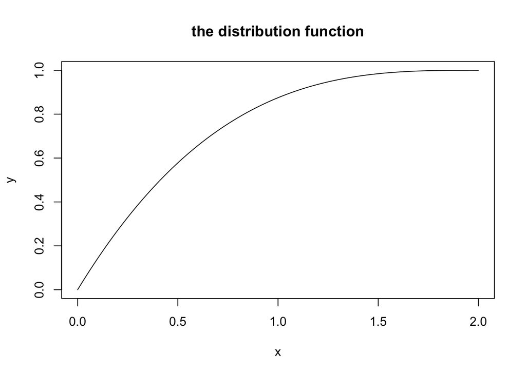

```r
x=seq(0,2,by=.01)
y=c()
for (i in 1:length(x)){
  y=c(y,F_example(x[i]))
}
plot(x,y,type="l",
     main="the distribution function")
```

## Estimating Moments

Recall, $E(X^n)$ is called the *$n$th moment about 0* of the distribution. The first moment is the expected value $E(X)$, and the 2nd and 1st together determine the variance: $V(X) = E(X^2)-E(X)^2.$

For a continuous random variable $X$ with pdf $f(x)$,
$$E(X^n)
= \int_{-\infty}^\infty x^n \cdot f(x).$$

In R we can numerically estimate these integrals with the `mid.sum()` function defined above, applied to the integrand $x^n\cdot f(X)$.

```r
moment.integrand<-function(f,n){
  #inputs:
      # f - a previously defined pdf
      # n - an integer
  #output: the integrand function for evaluating E(X^n)
  return(function(x){return(x^n*f(x))})
}
```

## Expected Value

For a continuous random variable $X$,
$$E(X)=\int_{-\infty}^{\infty} x \cdot
f(x)~dx.$$

To estimate this integral, we plug the first moment integrand $x \cdot f(x)$ into our Riemann sum function.

```r
mu=mid.sum(moment.integrand(f_pdf,1),0,2,100)
mu
```

```
## [1] 0.500025
```

Note: The actual expected value is

$$\int_0^2 x \cdot (3/8)(2-x)^2~dx =
0.5.$$

We estimate the **variance** knowing that $V(X) = E(X^2)-E(X)^2.$

```r
EX2=mid.sum(moment.integrand(f_pdf,2),0,2,100)
EX2
```

```
## [1] 0.4
```

So the variance of $X$ is

```r
EX2-mu^2
```

```
## [1] 0.149975
```

Note: The actual value of $E(X^2)$ is
$$\int_0^2 x^2 \cdot (3/8)(2-x)^2~dx =
0.4,$$
so $V(X) = 0.4 - (0.5)^2 = 0.15.$